# Propuesta Solución Taller 1

Maestría en Inteligencia de Negocios - UEC

Andrés Cruz Peréz

24/11/23

# Ejercicio 1

En Colombia hay bastante inquietud por la cantidad de robos que se presentan diariamente. Los celulares, motocicletas y bicicletas han sido los elementos más ansiados por los delincuentes en nuestro país, mientras que los carros y el robo de billeteras vienen a la baja. La cantidad total de robos en el país es una incógnita, ya que no siempre se reporta este delito en los entes de control. Por otro lado, la cantidad de homicidios en cada municipio del país si se reporta diariamente y se reporta ante las autoridades competentes. Se sospecha que estas dos variables, por municipio, están altamente correlacionadas. Tome la base de Delitos en Colombia, reestructure este conjunto de datos para:

Obtener una base de datos por municipios, que contenga la cantidad de delitos por temática, porcentaje de mujeres víctimas y porcentaje de delitos en zonas rural.

```r
Delitos <- read.csv("Delitos en Colombia.csv", encoding="UTF-8")

Delitos$Mujer=ifelse(Delitos$SEXO=="FEMENINO",1,0)
Delitos$Rural=ifelse(Delitos$ZONA=="RURAL",1,0)

Delitos2 = Delitos %>%  group_by (MUNICIPIO, TEMÁTICA) %>%
  dplyr ::summarise(n = n(),         Muj_Vic=sum(Mujer)/n*100,                      Del_Rur=sum(Rural)/n*100)

Delitos3 = Delitos2[,-c(4,5)] %>%  pivot_wider(names_from= TEMÁTICA, values_from=n)

Delitos4 = Delitos3 %>%
          filter(complete.cases(`HURTO A PERSONAS`,HOMICIDIOS))
head(Delitos4)
```

```
# A tibble: 6 × 13
# Groups:   MUNICIPIO [6]
  MUNICIPIO ABIGEATO AMENAZA `DELITOS SEXUALES` EXTORCIÓN HOMICIDIOS
  <chr>        <int>   <int>              <int>     <int>      <int>
1 ABEJORRAL        2       1                 11         2          8
2 ABREGO           1      24                 14         1         34
3 ACACÍAS         27     109                103        57         59
4 ACANDÍ          NA      10                 15         1         15
5 ACEVEDO         NA      59                 59         4         20
6 AGRADO           4      24                  7         1          1
# ℹ 7 more variables: `HURTO A PERSONAS` <int>, `HURTO A RESIDENCIAS` <int>,
#   `LESIONES PERSONALES` <int>, `VIOLENCIA INTRAFAMILIAR` <int>,
#   `CABEZA DE GANADO` <int>, `PIRATERIA TERRESTRE` <int>, SECUESTRO <int>
```

1.Explique si la cantidad de homicidios tiene una correlación alta con la cantidad de robos.

```r
cor(Delitos4$`HURTO A PERSONAS`, Delitos4$HOMICIDIOS)
```

```
[1] 0.8518
```

La correlación entre la cantidad de homicidios y la cantidad de hurtos a personas es alta 85%, es decir que entre mas hurtos a personas sucedan, el número de homicidios será mas alto.

2.Realice diagrama de barras de los diez municipios con mayor cantidad de delitos por temática y explique.

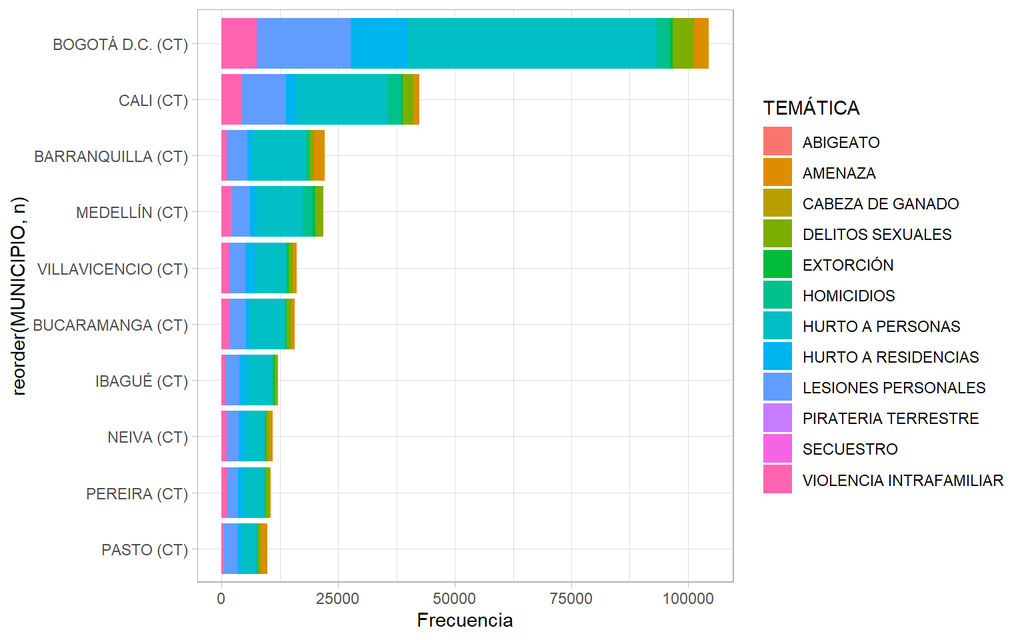

```r
Delitos5 = Delitos %>%  group_by (MUNICIPIO) %>%
  dplyr :: summarise(n = n()) %>%  top_n(10)
top=Delitos5$MUNICIPIO
delitos6=filter(Delitos2[,-c(4,5)], MUNICIPIO %in% top)


ggplot(delitos6, aes(fill=TEMÁTICA, y=n, x=reorder(MUNICIPIO,n))) +
  geom_bar(position="stack", stat="identity")+theme_light ()+
  labs(y="Frecuencia")+
  coord_flip()
```

3.Realice histogramas de la razón de homicidios de hombres sobre homicidios de mujeres.

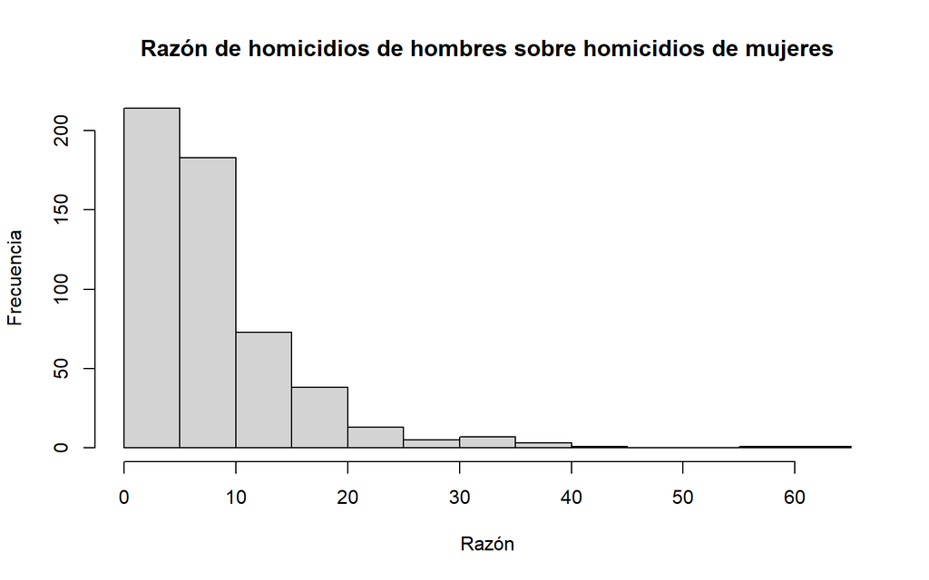

```r
Delitos7 = Delitos %>%  group_by (TEMÁTICA, SEXO,MUNICIPIO) %>%
  dplyr :: summarise(n = n())
Delitos8=filter(Delitos7, SEXO %in% c("FEMENINO","MASCULINO"))
Delitos9=filter(Delitos8, TEMÁTICA %in% c("HOMICIDIOS"))
Delitos10 = Delitos9 %>%  pivot_wider(names_from= SEXO, values_from=n)
Delitos10$Razon=Delitos10$MASCULINO/Delitos10$FEMENINO
hist(Delitos10$Razon,xlab="Razón",ylab="Frecuencia", main = "Razón de homicidios de hombres sobre homicidios de mujeres")
```

Obtener una base de datos para Bogotá.

```r
Delitos_Bog = Delitos %>% filter(MUNICIPIO=="BOGOTÁ D.C. (CT)")
head(Delitos_Bog)
```

```
  TEMÁTICA      FECHA DEPARTAMENTO        MUNICIPIO       DIA  HORA
1 ABIGEATO            CUNDINAMARCA BOGOTÁ D.C. (CT) Miércoles  5:00
2 ABIGEATO            CUNDINAMARCA BOGOTÁ D.C. (CT)   Viernes 17:00
3 ABIGEATO            CUNDINAMARCA BOGOTÁ D.C. (CT)    Sábado  6:10
4 ABIGEATO            CUNDINAMARCA BOGOTÁ D.C. (CT)    Sábado  6:00
5 ABIGEATO            CUNDINAMARCA BOGOTÁ D.C. (CT) Miércoles  3:00
6 ABIGEATO 05/03/2014 CUNDINAMARCA BOGOTÁ D.C. (CT) Miércoles  1:00
                 BARRIO   ZONA         CLASE.SITIO       ARMA.EMPLEADA
1       EL MIRADOR E-19  RURAL  FINCAS Y SIMILARES SIN EMPLEO DE ARMAS
2         TURINGIA E-11 URBANA       VIAS PUBLICAS SIN EMPLEO DE ARMAS
3     LAS MERCEDES E-11  RURAL            POTREROS         ARMA BLANCA
4    CIUDAD BOGOTA E-19  RURAL  FINCAS Y SIMILARES SIN EMPLEO DE ARMAS
5 VEREDA MONSERRATE E-3  RURAL  FINCAS Y SIMILARES SIN EMPLEO DE ARMAS
6    SAN BERNARDINO E-7 URBANA CASAS DE HABITACION SIN EMPLEO DE ARMAS
  MOVIL.AGRESOR MOVIL.VICTIMA EDAD      SEXO ESTADO.CIVIL PAIS.NACE
1         A PIE         A PIE   43 MASCULINO       CASADO  COLOMBIA
2         A PIE         A PIE   40 MASCULINO  UNION LIBRE  COLOMBIA
3         A PIE         A PIE   69 MASCULINO  UNION LIBRE  COLOMBIA
4         A PIE         A PIE   51  FEMENINO       CASADO  COLOMBIA
5         A PIE         A PIE   69 MASCULINO       CASADO  COLOMBIA
6         A PIE         A PIE   66 MASCULINO       CASADO  COLOMBIA
       CLASE.EMPLEADO    PROFESION ESCOLARIDAD CODIGO.DANE Mujer Rural
1 EMPLEADO PARTICULAR NO REPORTADO  SECUNDARIA    11001000     0     1
2       INDEPENDIENTE NO REPORTADO  SECUNDARIA    11001000     0     0
3       INDEPENDIENTE NO REPORTADO  SECUNDARIA    11001000     0     1
4 EMPLEADO PARTICULAR   LICENCIADO    SUPERIOR    11001000     1     1
5          PENSIONADO NO REPORTADO    SUPERIOR    11001000     0     1
6       INDEPENDIENTE NO REPORTADO    PRIMARIA    11001000     0     0
```

1.Reclasiﬁque el tipo de arma empleada en las siguientes categorías: Sin empleo de armas, arma de fuego, arma blanca y otra.

```r
Delitos_Bog$Tipo_Arma[Delitos_Bog$ARMA.EMPLEADA =="SIN EMPLEO DE ARMAS"] = "Sin empleo de armas"
Delitos_Bog$Tipo_Arma[Delitos_Bog$ARMA.EMPLEADA=="ARMA DE FUEGO"] = "Arma de fuego"
Delitos_Bog$Tipo_Arma[Delitos_Bog$ARMA.EMPLEADA =="ARMA BLANCA"] = "Arma blanca"
Delitos_Bog$Tipo_Arma[is.na(Delitos_Bog$Tipo_Arma)] = "Otra"
```

2.Calcule la proporción de delitos cometidos en Bogotá, por cada tipo de arma empleada. Para eso, utilice la clasiﬁcación obtenida en el punto anterior.

```r
kable(prop.table(table(Delitos_Bog$Tipo_Arma))*100)
```

| Var1 | Freq |
| --- | --- |
| Arma blanca | 10.12 |
| Arma de fuego | 11.33 |
| Otra | 44.73 |
| Sin empleo de armas | 33.81 |

3.Realice una tabla cruzada que contemple las variables sexo y el tipo de delito. ¿Cuál es la proporción de víctimas por tipo para cada sexo?

```r
Delitos_Bog1=filter(Delitos_Bog, SEXO %in% c("FEMENINO","MASCULINO"))
kable(t(round(prop.table(table(Delitos_Bog1$SEXO, Delitos_Bog1$TEMÁTICA),2)*100,2)))
```

|  | FEMENINO | MASCULINO |
| --- | --- | --- |
| ABIGEATO | 10.00 | 90.00 |
| AMENAZA | 51.49 | 48.51 |
| CABEZA DE GANADO | 31.03 | 68.97 |
| DELITOS SEXUALES | 86.67 | 13.33 |
| EXTORCIÓN | 32.46 | 67.54 |
| HOMICIDIOS | 10.89 | 89.11 |
| HURTO A PERSONAS | 33.77 | 66.23 |
| HURTO A RESIDENCIAS | 47.85 | 52.15 |
| LESIONES PERSONALES | 40.89 | 59.11 |
| PIRATERIA TERRESTRE | 0.00 | 100.00 |
| SECUESTRO | 39.62 | 60.38 |
| VIOLENCIA INTRAFAMILIAR | 83.00 | 17.00 |

4.Realice diagramas de caja donde se evidencie la comparación de la distribución de las edades y el tipo de arma empleada en los delitos.

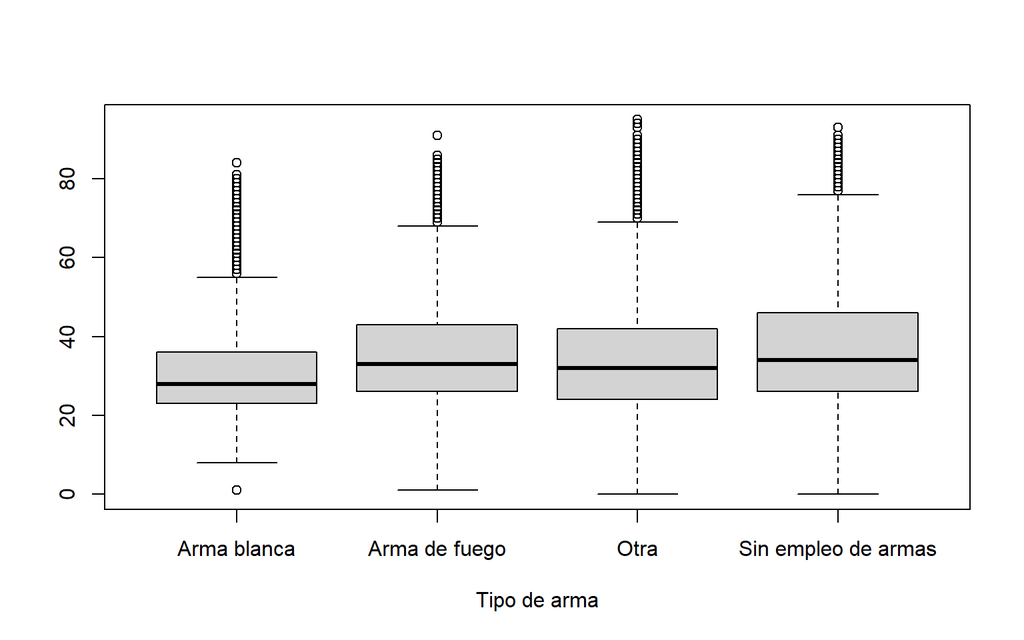

```r
boxplot(as.numeric(Delitos_Bog$EDAD)~Delitos_Bog$Tipo_Arma, xlab = "Tipo de arma", ylab = "")
```

# Ejercicio 2

La generación y consolidación de ventajas competitivas al interior de una empresa guarda una estrecha relación con las condiciones de su entorno. Tales condiciones resultan importantes no sólo para la generación de valor en el nivel individual de la ﬁrma, sino también inciden en los procesos de generación de riqueza de sociedades enteras. El concepto de cadena productiva ofrece un marco conceptual útil para la articulación de diferentes unidades empresariales de cara al proceso de generación de valor y el papel que cumple cada una de las empresas que intervienen en el mismo. Para este estudio, trabajaremos con la cadena productiva rural. Tome las bases de Cadena Productiva y Cultivos ilícitos, reestructure estos conjuntos de datos para:

Obtener una base de datos por municipios que discrimine la producción, en términos de área sembrada y cosechada, por grupos de cultivos para los años 2007-2015. Plantee gráﬁcos de línea para evaluar el crecimiento o decrecimiento de cada uno de los grupos.

```r
Cadena_Productiva <- read_excel("Cadena_Productiva.xlsx", sheet = "in")

Cadena_Productiva2 = Cadena_Productiva %>% group_by(MUNICIPIO, `GRUPO DE CULTIVO`, PERIODO2) %>%
  summarise(Area_Cos=sum(`Area Cosechada(ha)`),
            Area_Sem=sum(`Area Sembrada(ha)`),
            Producc=sum(Produccion))

Cadena_Productiva3 = Cadena_Productiva %>% group_by( `GRUPO DE CULTIVO`, PERIODO2) %>%
  summarise(Area_Cos=sum(`Area Cosechada(ha)`),
            Area_Sem=sum(`Area Sembrada(ha)`),
            Producc=sum(Produccion))
head(Cadena_Productiva3)
```

```
# A tibble: 6 × 5
# Groups:   GRUPO DE CULTIVO [1]
  `GRUPO DE CULTIVO` PERIODO2 Area_Cos Area_Sem Producc
  <chr>                 <dbl>    <dbl>    <dbl>   <dbl>
1 CEREALES               2006   466373   487162 1571130
2 CEREALES               2007  1038286  1107558 3834770
3 CEREALES               2008  1085627  1149379 4098391
4 CEREALES               2009  1073840  1148698 3991779
5 CEREALES               2010   961904  1113811 3415716
6 CEREALES               2011  1052036  1140464 3545985
```

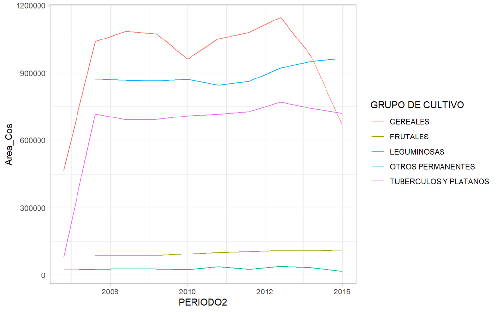

```r
ggplot(data=Cadena_Productiva3, aes(x=PERIODO2, y=Area_Cos, group= `GRUPO DE CULTIVO`)) +  geom_line(aes(color=`GRUPO DE CULTIVO`))+theme_light ()
```

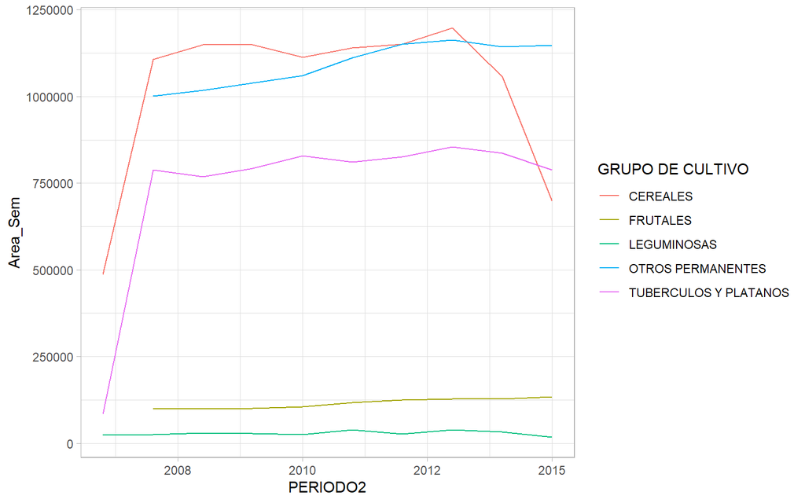

```r
ggplot(data=Cadena_Productiva3, aes(x=PERIODO2, y=Area_Sem, group= `GRUPO DE CULTIVO`)) +  geom_line(aes(color=`GRUPO DE CULTIVO`))+theme_light ()
```

Haga un cruce de las bases de datos (join o merge). Una de ellas es la asociada a los Cultivos ilícitos y otra que fue obtenida en el punto anterior y calcule el porcentaje de cultivos ilícitos para cada municipio en 2015 Total Cultivos ilícitos

```r
Cultivos_Ilicitos_2015_2019 <- read_excel("Cultivos Ilicitos 2015-2019.xlsx")
Cultivos_Ilicitos_2015_2019 = Cultivos_Ilicitos_2015_2019[,c(4,5)]
colnames(Cultivos_Ilicitos_2015_2019)=c("MUNICIPIO", "Ilicitos")


Cadena_Productiva4 = Cadena_Productiva %>% group_by(MUNICIPIO, PERIODO2) %>%
  summarise(Area_Sem=sum(`Area Sembrada(ha)`))


Cadena_Productiva5 = Cadena_Productiva4 %>%  pivot_wider(names_from= PERIODO2, values_from=Area_Sem)
Cadena_Productiva6 = Cadena_Productiva5[,c(1,11)]

colnames(Cadena_Productiva6)=c("MUNICIPIO", "Licitos")

Cultivos <-merge(x = Cadena_Productiva6, y = Cultivos_Ilicitos_2015_2019, by = "MUNICIPIO", all.x = T)

Cultivos$Ilicitos[is.na(Cultivos$Ilicitos)] = 0

Cultivos$Porc_Ili=Cultivos$Ilicitos/(Cultivos$Ilicitos+Cultivos$Licitos)*100

Top20 = Cultivos %>%  arrange(desc(Porc_Ili)) %>% top_n(20)
```

Después haga un gráﬁco de barras con los 20 municipios con mayor porcentaje de cultivos ilícitos y saque conclusiones.

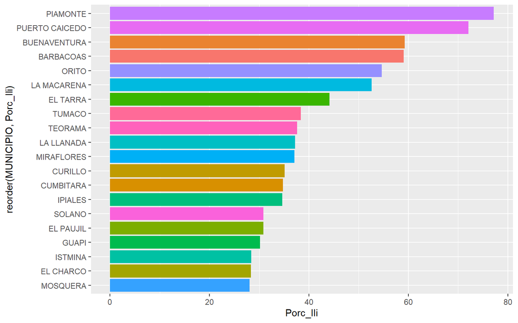

```r
ggplot(Top20, aes(y=Porc_Ili, x=reorder(MUNICIPIO,Porc_Ili), fill=MUNICIPIO)) +  geom_bar( stat="identity")+
  coord_flip()+ theme(legend.position = "none")
```